# การนำเสนอโครงงาน | Calculus Learning Sandbox (สอบป้องกันโครงงาน)

KU สาขาวิชาคณิตศาสตร์ประยุกต์ • ภาควิชาวิทยาการคำนวณและเทคโนโลยีดิจิทัล

[เปิดแอปจริง](https://calculus-integration-app-dwdsz8vq2omsddezfjvday.streamlit.app/)

รายงานโครงงานคณิตศาสตร์ประยุกต์ ประจำปีการศึกษา 2569

การพัฒนาเว็บแอปพลิเคชันช่วยเรียนคณิตศาสตร์  
สำหรับแคลคูลัสเบื้องต้น

Development of a Math Tutor Web Application for Introductory Calculus

01 / 33

ผู้จัดทำ

นางสาวขวัญเรือน สำเนียงดี (6621602928)  
นางสาวเบญจกัฬยาณี พิทยากูล (6621602979)

อาจารย์ที่ปรึกษา

อาจารย์ ดร.กิตติพงศ์ ทรัพย์วัฒนาชัย

ภาควิชา

วิทยาการคำนวณและเทคโนโลยีดิจิทัล  
คณะศิลปศาสตร์และวิทยาศาสตร์ มก.

**โครงสร้างการนำเสนอ 28–30 นาที** บทนำและเปรียบเทียบเครื่องมือ → สถาปัตยกรรม → เนื้อหาและตัวอย่างคำนวณบทที่ 2 (7 โมดูล x 2 สไลด์) → การทดสอบ 265 ข้อ → การประเมินผู้ใช้จริง

1. ที่มาและความสำคัญ · สภาพปัญหาในการเรียนแคลคูลัส

สามปัญหาสำคัญที่พบในการจัดการเรียนการสอนแคลคูลัสระดับมหาวิทยาลัย

02 / 33

1. ความซับซ้อนของมโนทัศน์

นิสิตส่วนใหญ่ประสบปัญหาในหัวข้อ **ลิมิต อนุพันธ์ และปริพันธ์** เนื่องจากเป็นแนวคิดเชิงนามธรรม ที่ต้องอาศัยการเชื่อมโยงอย่างแนบแน่นระหว่าง **เรขาคณิตและพีชคณิต**

2. ขาดความเข้าใจเงื่อนไขและที่มา

ผู้เรียนมักจดจำเฉพาะ **สูตรสำเร็จในการคำนวณ** แต่ขาดความเข้าใจในเงื่อนไขการใช้สูตร เช่น เงื่อนไขความต่อเนื่อง ขอบเขตการอินทิเกรต หรือพฤติกรรมของฟังก์ชัน ณ จุดวิกฤต

3. สื่อการเรียนรู้กระจัดกระจาย

เนื้อหา ตัวอย่าง และแบบฝึกหัดที่มีอยู่ทั่วไปมักกระจัดกระจาย ขาดการจัดหมวดหมู่อย่างเป็นระบบ และไม่มีระบบที่รวบรวมเครื่องมือคำนวณพร้อมคำอธิบายภาษาไทยไว้ในที่เดียว

**แรงบันดาลใจในการวิจัย:** พัฒนาสื่อการเรียนรู้ดิจิทัลภาษาไทยที่เป็นเสมือน "ห้องทดลองทางคณิตศาสตร์" ให้ผู้เรียนสามารถทดลองปรับค่า สังเกตพฤติกรรมกราฟ และทำความเข้าใจที่มาของสูตรด้วยตนเอง

1. ที่มาและความสำคัญ · ปัญหามโนทัศน์ที่มองไม่เห็น

สามจุดบอดทางมโนทัศน์ที่ผู้เรียนคำนวณได้ แต่จินตนาการภาพไม่ออก

03 / 33

จุดที่ 1 · ลิมิตเข้าใกล้จุด

รูปแบบยังไม่กำหนด $\frac{0}{0}$ ผู้เรียนมักท่องจำว่า "แยกตัวประกอบแล้วตัดทอน" แต่ไม่เคยเห็นว่าค่าฟังก์ชันวิ่งเข้าสู่ค่าจริงอย่างไร และทำไมกราฟจึงเกิดจุดโปร่ง

$$\lim_{x\to 3}\frac{x^2-9}{x-3} = 6$$

จุดที่ 2 · อนุพันธ์และเส้นสัมผัส

คำว่า $h\to 0$ ในนิยามอนุพันธ์เป็นนามธรรม ผู้เรียนไม่เห็นการหมุนของเส้นตัดโค้งเข้าทาบเส้นสัมผัส และไม่เข้าใจว่าทำไมจุดมุมแหลม $|x|$ จึงหาอนุพันธ์ไม่ได้

$$f'(a)=\lim_{h\to 0}\frac{f(a+h)-f(a)}{h}$$

จุดที่ 3 · ปริพันธ์ผลรวมรีมันน์

ผลบวกของพื้นที่สี่เหลี่ยมผืนผ้ากลายเป็นพื้นที่ใต้เส้นโค้งได้อย่างไร ตัวเชื่อมโยงที่แท้จริงคือการลู่เข้าเมื่อ $n\to\infty$ ไม่ใช่การท่องจำสูตรอินทิเกรต

$$\lim_{n\to\infty}\sum_{i=1}^{n} f(x_i^*)\,\Delta x = \int_a^b f(x)\,dx$$

**หลักการสำคัญ:** ปัญหาไม่ได้อยู่ที่ผู้เรียนคิดเลขไม่เป็น แต่อยู่ที่ **ไม่มีภาพจำลองทางเรขาคณิต (Concept Image)** ที่สอดคล้องกับนิยามทางคณิตศาสตร์ (Concept Definition)

1. ที่มาและความสำคัญ · การวิเคราะห์เปรียบเทียบระบบ

การวางตำแหน่งเครื่องมือ: AI Chat vs WolframAlpha vs GeoGebra/Desmos vs เรา

04 / 33

| มิติการเปรียบเทียบ | ปัญญาประดิษฐ์ (AI Chat) | WolframAlpha | GeoGebra / Desmos | Calculus Sandbox (เรา) |
| --- | --- | --- | --- | --- |
| **1. รูปแบบการโต้ตอบ** | ทางเดียว (ถามแล้วอ่านคำตอบยาว) | ทางเดียว (ใส่โจทย์แล้วดูผลลัพธ์) | ปรับกราฟอิสระ (ไม่มีโจทย์ในตัว) | **โต้ตอบสองทาง มีโครงสร้างนำทาง** |
| **2. บทบาทต่อผู้เรียน** | บอกวิธีทำทั้งหมดในคราวเดียว | แสดงคำตอบทันที (วิธีทำเสียเงิน) | วาดกราฟ ไม่มีระบบสอนในตัว | **ห้องทดลองฝึกคิด มีคำใบ้ 3 ระดับ** |
| **3. การจัดการจุดเข้าใจผิด** | ตอบตามฉลาดโมเดล | ตรวจไม่ได้ แจ้งแค่ไวยากรณ์ผิด | ตรวจไม่ได้ วาดตามที่พิมพ์ | **ตรวจจับ Misconceptions แจ้งเตือนสด** |
| **4. ต้นทุนและการเข้าถึง** | โมเดลคิดวิเคราะห์มีค่าบริการ | วิธีทำละเอียดมีค่าบริการสูง | ฟรี แต่ต้องเชี่ยวชาญพิมพ์สูตร | **โอเพนซอร์ส 100% ฟรีผ่านเว็บ** |

อ้างอิงตารางที่ 3 ในเล่ม และสไลด์นำเสนอหัวข้อ: ระบบของเราออกแบบขึ้นเพื่อเป็น **นั่งร้านทางปัญญา (Scaffolding)** สำหรับผู้เรียนไทยโดยเฉพาะ

2. วัตถุประสงค์ของโครงงาน

เป้าหมายเชิงพัฒนาระบบ การศึกษา และการประเมินผล 5 ข้อ

05 / 33

วัตถุประสงค์ 5 ข้อหลัก

1. **พัฒนาเว็บแอปพลิเคชัน:** ด้วยภาษา Python และ Streamlit เพื่อเป็นสื่อการเรียนรู้เชิงโต้ตอบสำหรับแคลคูลัสเบื้องต้น
2. **รวบรวมเนื้อหาครบวงจร:** รวบรวมทฤษฎี ตัวอย่างคำนวณทีละขั้น และแบบฝึกหัด 7 โมดูลไว้ในระบบเดียวอย่างเป็นหมวดหมู่
3. **สร้างระบบคำนวณสัญลักษณ์ (CAS):** ใช้ SymPy ประมวลผลและแสดงขั้นตอนวิธีทำทางคณิตศาสตร์อย่างถูกต้องแม่นยำ
4. **พัฒนากลไกป้องกันข้อผิดพลาด:** ตรวจจับและแจ้งเตือนจุดเข้าใจผิด (Misconceptions) ที่พบบ่อยในแต่ละหัวข้อ
5. **ประเมินความพึงพอใจและ SUS:** ประเมินความสะดวกในการใช้งานกับผู้เรียนจริงตามเกณฑ์มาตรฐานสากล

ประโยชน์ที่คาดว่าจะได้รับ

- ผู้เรียนมีเครื่องมือทบทวนมโนทัศน์และฝึกแก้โจทย์ด้วยตนเองได้ทุกที่ทุกเวลา
- ลดภาระการจดจำสูตรโดยไม่เข้าใจเงื่อนไข ผ่านการทดลองปรับค่าพารามิเตอร์บนกราฟ
- อาจารย์ผู้สอนมีสื่อสาธิตทางคณิตศาสตร์เชิงโต้ตอบภาษาไทยใช้ประกอบการบรรยาย
- เป็นต้นแบบเว็บแอปพลิเคชันเพื่อการศึกษาที่ต่อยอดในวิชาคณิตศาสตร์ขั้นสูงได้

2. ขอบเขตการศึกษาและเทคโนโลยีที่ใช้

กรอบเทคโนโลยี และขอบเขตเนื้อหา 7 โมดูลบทเรียน

06 / 33

กรอบเทคโนโลยีที่เลือกใช้ (Technology Stack)

- **ภาษาหลัก:** Python 3.10+ ประสิทธิภาพสูง รองรับงานวิทยาศาสตร์ข้อมูล
- **ส่วนติดต่อผู้ใช้ (UI):** Streamlit Framework สำหรับ Web App เชิงโต้ตอบ
- **ระบบคำนวณสัญลักษณ์:** SymPy (Computer Algebra System) คำนวณตรงรูปแท้จริง
- **การพล็อตกราฟิก:** Matplotlib + NumPy สำหรับวาดเส้นโค้งและพื้นที่เรขาคณิต 2D
- **การเรนเดอร์สมการ:** KaTeX แสดงผลสูตรคณิตศาสตร์สวยงามตามมาตรฐาน LaTeX

ขอบเขตเนื้อหา 7 โมดูลหลัก

M1

ลิมิตและความต่อเนื่อง

M2

เส้นสัมผัสและอนุพันธ์

M3

ผลรวมรีมันน์

M4

การแทนค่าตัวแปร $u$

M5

พื้นที่ระหว่างเส้นโค้ง

M6

ปริมาตรทรงตันจากการหมุน

M7

ปริพันธ์ไม่ตรงแบบ

+

คลังข้อสอบมโนทัศน์ 80 ข้อ

ขอบเขต: รองรับฟังก์ชันมูลฐานมาตรฐาน พหุนาม ตรีโกณ เอกซ์โพเนนเชียล ลอการิทึม หมุนรอบแกน $x$

3. วิธีดำเนินงาน · สถาปัตยกรรมระบบ 3 ชั้น

จากเนื้อหาบทเรียน ผ่านการประมวลผล สู่การใช้งานบนเว็บ

07 / 33

1. ส่วนติดต่อผู้ใช้ (Frontend)

**Streamlit** รับฟังก์ชันและพารามิเตอร์ แสดงบทเรียน วิธีทำ และกราฟโต้ตอบ

2. บริการประมวลผล (Backend)

**SymPy** คำนวณเชิงสัญลักษณ์ ร่วมกับการตรวจเงื่อนไขและ **Matplotlib** สำหรับกราฟ

3. จัดเก็บข้อมูล (Data & Storage)

แยกเนื้อหาบทเรียน **Markdown** และคลังข้อสอบ **JSON** ออกจากตรรกะประมวลผล

3. วิธีดำเนินงาน · นั่งร้านทางปัญญา 4 ระดับ

การจัดลำดับการเรียนรู้ตามหลัก Cognitive Load (Sweller, 1988)

08 / 33

ระดับ 1

เห็นภาพ (Visualizing)

ปรับค่าพารามิเตอร์ผ่านแถบเลื่อน (Slider) แล้วเห็นกราฟขยับตามทันที

ระดับ 2

เห็นโครงสร้าง (Structuring)

คลี่ดูวิธีทำทีละขั้น พร้อมทฤษฎีบทกำกับในแต่ละขั้นตอนอย่างเป็นลำดับ

ระดับ 3

ลองทำเอง (Practicing)

ทำแบบทดสอบมโนทัศน์ที่มีคำใบ้ 3 ระดับ ไม่บอกคำตอบสุดท้ายทันที

ระดับ 4

ตรวจจุดผิด (Self-Correcting)

แจ้งเตือน $\frac{0}{0}$, จุดโปร่ง, จุดมุมแหลม, จุดเอกฐาน, หรือพื้นที่ติดลบ

**ทำไมต้องมีครบทั้ง 4 ระดับ:** หากมีแต่กราฟ ผู้เรียนจะได้เพียงความเพลิดเพลินแต่เขียนวิธีทำไม่เป็น • หากมีแต่เฉลย ผู้เรียนจะขาดการคิดวิเคราะห์ • การผสาน 4 ระดับช่วยให้เกิด **การตรวจสอบตนเอง (Metacognition)**

3. วิธีดำเนินงาน · ขั้นตอนการดำเนินงาน 4 ขั้นตอน

วงจรการพัฒนาระบบ: Plan & Design • Content • Development • Test & Deploy

09 / 33

ขั้นตอนที่ 1 · Plan & Design

กำหนดวัตถุประสงค์การเรียนรู้ตามหลักสูตร มก. จัดทำโครงสร้างบทเรียน และออกแบบ Wireframe / UI Mockup สไตล์ Bauhaus Pop

ขั้นตอนที่ 2 · Content Synthesis

สังเคราะห์เนื้อหาทฤษฎีแคลคูลัส 7 หัวข้อ จัดทำขั้นตอนวิธีทำตัวอย่างโจทย์ และเตรียมคลังข้อสอบมโนทัศน์ 80 ข้อพร้อมคำใบ้ 3 ระดับ

ขั้นตอนที่ 3 · System Development

พัฒนาเว็บแอปด้วย Python + Streamlit สร้างโมดูลคำนวณ SymPy Solver และโมดูลวาดกราฟิก Matplotlib Plotter

ขั้นตอนที่ 4 · Test & Cloud Deployment

ทดสอบความถูกต้องด้วย Pytest 265 ข้อ, ทดสอบขอบเขต 144 เคส นำขึ้น Streamlit Community Cloud และประเมินผู้ใช้จริง $N=50$ คน

3. วิธีดำเนินงาน · การเข้าถึงระบบจริง (Live Access)

ช่องทางการเข้าใช้งานเว็บแอปพลิเคชันบน Streamlit Cloud และคลังรหัสต้นฉบับ

10 / 33

ช่องทางการใช้งานระบบจริง

ระบบได้รับการติดตั้งและเปิดให้ใช้งานสาธารณะผ่าน **Streamlit Community Cloud**:

https://calculus-integration-app-dwdsz8vq2omsddezfjvday.streamlit.app/

- รองรับการใช้งานผ่านเว็บเบราว์เซอร์ทุกแพลตฟอร์ม (PC, Tablet, Mobile)
- ไม่ต้องติดตั้งโปรแกรมหรือไลบรารีใดๆ เพิ่มเติมบนเครื่องผู้เรียน
- ซอร์สโค้ดเปิดเผยแบบ Open Source บน GitHub

สแกนเพื่อเปิดแอปพลิเคชันจริง

[figure not shown]

สแกนด้วยสมาร์ตโฟนหรือแท็บเล็ตเพื่อร่วมทดสอบพร้อมกัน

2.1.1 ทฤษฎี · ลิมิตและความต่อเนื่อง

นิยามลิมิตสองด้าน ความต่อเนื่อง 3 เงื่อนไข และกฎโลปิตาล

11 / 33

นิยามลิมิตและความต่อเนื่อง

ลิมิตของ $f(x)$ เมื่อ $x\to a$ จะมีค่าเท่ากับ $L$ ก็ต่อเมื่อลิมิตซ้ายและขวามีค่าเท่ากัน:

$$\lim_{x\to a^-} f(x) = \lim_{x\to a^+} f(x) = L$$

ฟังก์ชันจะ **ต่อเนื่อง ณ จุด $x = a$** ก็ต่อเมื่อครบ 3 เงื่อนไข:

1. $f(a)$ นิยามและหาค่าได้ในโดเมน
2. $\lim_{x\to a} f(x)$ หาค่าได้เป็นจำนวนจริง
3. $\lim_{x\to a} f(x) = f(a)$

รูปแบบยังไม่กำหนด และกฎโลปิตาล

เมื่อแทนค่าแล้วได้รูปแบบยังไม่กำหนด $\left[\frac{0}{0}\right]$ หรือ $\left[\frac{\infty}{\infty}\right]$ หาก $f$ และ $g$ หาอนุพันธ์ได้บนช่วงเปิดรอบจุด $a$ และ $g'(x) \neq 0$ จะได้:

$$\lim_{x\to a} \frac{f(x)}{g(x)} = \lim_{x\to a} \frac{f'(x)}{g'(x)}$$

ระบบของเรารองรับทั้งการแยกตัวประกอบพีชคณิต และการตรวจสอบด้วยอนุพันธ์โลปิตาล

2.1.1 ตัวอย่าง · ลิมิตและการจัดการรูปแบบ 0/0

ตัวอย่างที่ 2.2: การคำนวณลิมิต ตารางลู่เข้า

12 / 33

ตัวอย่างที่ 2.2

จงหาค่าของ $\lim_{x\to 3}\frac{x^2-9}{x-3}$ ซึ่งแทนค่าแล้วได้ $\left[\frac{0}{0}\right]$

$$\lim_{x\to 3}\frac{(x-3)(x+3)}{x-3} = \lim_{x\to 3}(x+3) = 6$$

**ตารางจำลองค่าลู่เข้าเชิงตัวเลขของระบบ:**

| $x$ ซ้าย | $f(x)$ | $x$ ขวา | $f(x)$ |
| --- | --- | --- | --- |
| 2.9 | 5.900 | 3.1 | 6.100 |
| 2.99 | 5.990 | 3.01 | 6.010 |
| 2.999 | 5.999 | 3.001 | 6.001 |

**จุดเตือนของระบบ:** แม้ $f(3)$ จะไม่นิยามในโดเมน แต่ลิมิตหาค่าได้ กราฟจะแสดง **จุดโปร่ง (Hole)** ที่พิกัด $(3, 6)$ อย่างชัดเจน ป้องกันการสับสนระหว่างค่าฟังก์ชันกับลิมิต

🌐 หน้าจอเว็บแอปจริง · ลิมิตเข้าใกล้จุด 🔍 คลิกขยาย

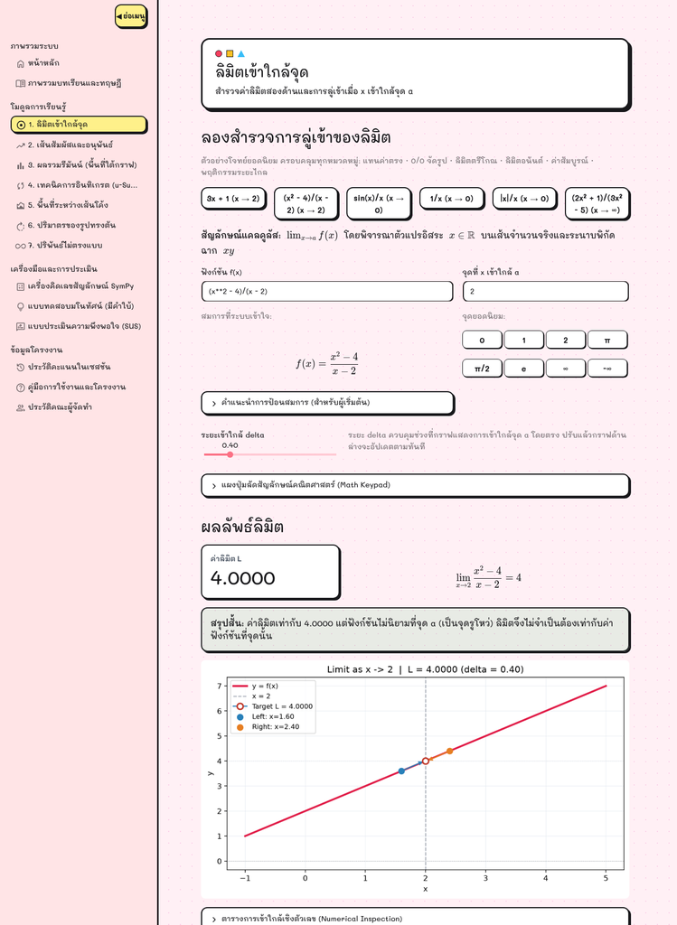

2.1.2 ทฤษฎี · เส้นสัมผัสและอนุพันธ์

การแปลงจากเส้นตัดโค้งสู่เส้นสัมผัส และทฤษฎีบทการหาอนุพันธ์ได้

13 / 33

นิยามอนุพันธ์ผ่านความชันเส้นตัดโค้ง

ความชันของเส้นตัดโค้ง (Secant Line) ผ่านจุด $P(a, f(a))$ และ $Q(a+h, f(a+h))$ คือ:

$$m_{\text{sec}} = \frac{f(a+h) - f(a)}{h}$$

เมื่อ $h \to 0$ จุด $Q$ เลื่อนเข้าทับจุด $P$ เส้นตัดโค้งจะกลายเป็น **เส้นสัมผัส (Tangent Line)**:

$$f'(a) = \lim_{h\to 0} \frac{f(a+h) - f(a)}{h}$$

ทฤษฎีบทการหาอนุพันธ์ได้และความต่อเนื่อง

**ทฤษฎีบท:** ถ้า $f$ สามารถหาอนุพันธ์ได้ที่จุด $x = a$ แล้ว $f$ ย่อมมีความต่อเนื่องที่จุด $x = a$ เสมอ

**บทกลับไม่เป็นจริง:** ฟังก์ชันต่อเนื่องไม่จำเป็นต้องหาอนุพันธ์ได้ เช่น กรณี **จุดมุมแหลม (Corner Point)** หรือ **เส้นสัมผัสแนวดิ่ง (Vertical Tangent)**

2.1.2 ตัวอย่าง · อนุพันธ์และกับดักจุดมุมแหลม

ตัวอย่างที่ 2.3: หาสมการเส้นสัมผัส $x^2$ และการดักจับจุดมุมแหลม $|x|$

14 / 33

ตัวอย่างที่ 2.3

จงหาความชันและสมการเส้นสัมผัสของ $f(x) = x^2$ ที่จุด $x = 1$

$$f'(1) = \lim_{h\to 0}\frac{(1+h)^2 - 1^2}{h} = \lim_{h\to 0}\frac{2h+h^2}{h} = 2$$

จุดสัมผัสคือ $(1, 1)$ ความชัน $m = 2$ หาสมการเส้นสัมผัสได้คือ:

$$y - 1 = 2(x - 1) \implies y = 2x - 1$$

🌐 หน้าจอเว็บแอปจริง · เส้นสัมผัสและการดักจับจุดมุมแหลม 🔍 คลิกขยาย

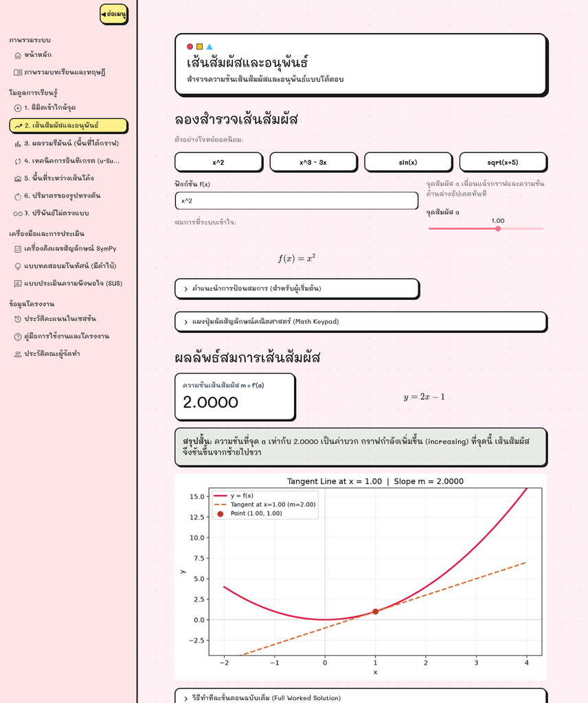

2.1.3 ทฤษฎี · ผลรวมรีมันน์และทฤษฎีบทหลักมูล

นิยามผลรวมรีมันน์ 3 รูปแบบ และทฤษฎีบทหลักมูลของแคลคูลัส (FTC 1 & 2)

15 / 33

นิยามผลรวมรีมันน์ (Riemann Sum)

แบ่งช่วง $[a, b]$ ออกเป็น $n$ ช่วงย่อย ความกว้าง $\Delta x = \frac{b-a}{n} \\$ และ $x_i = a+i\Delta x$ เมื่อ $i = 1,2,\ldots, n$

- **ผลรวมซ้าย:** $L_n = \sum_{i=1}^n f(x_{i-1})\Delta x$
- **ผลรวมขวา:** $R_n = \sum_{i=1}^n f(x_i)\Delta x$
- **จุดกึ่งกลาง:** $M_n = \sum_{i=1}^n f(x_i^*)\Delta x$ โดย $x_i^* = a + (i-0.5)\Delta x$

$$\int_a^b f(x)\,dx = \lim_{n\to\infty} \sum_{i=1}^n f(x_i^*)\,\Delta x$$

ทฤษฎีบทหลักมูลของแคลคูลัส (FTC)

**Theorem 1:** ถ้า $f$ ต่อเนื่องบน $[a, b]$ และ $g(x) = \int_a^x f(t)dt$ แล้ว $g'(x) = f(x)$

**Theorem 2:** ถ้า $F'(x) = f(x)$ แล้ว $\int_a^b f(x)dx = F(b) - F(a)$

FTC คือสะพานเชื่อมระหว่าง "พื้นที่จากการลู่เข้าของรีมันน์" กับ "ปฏิยานุพันธ์"

2.1.3 ตัวอย่าง · ตรรกะขั้นตอนวิธีผลรวมรีมันน์

ตัวอย่างที่ 2.7: การลู่เข้าของ $x^2$ บน $[0, 2]$ และความแม่นยำของจุดกึ่งกลาง

16 / 33

ค่าจริงเชิงสัญลักษณ์: $$\int_0^2 x^2\,dx = \frac{8}{3} \approx 2.6667$$ ทั้งสามวิธีลู่เข้าหาค่านี้

| จำนวนช่วง $n$ | ผลรวมซ้าย $L_n$ | Error ซ้าย | ผลรวมขวา $R_n$ | Error ขวา | จุดกึ่งกลาง $M_n$ | Error กึ่งกลาง |
| --- | --- | --- | --- | --- | --- | --- |
| 4 | 1.7500 | -34.38% | 3.7500 | +40.63% | 2.6250 | -1.56% |
| 10 | 2.2800 | -14.50% | 3.0800 | +15.50% | 2.6600 | -0.25% |
| 20 | 2.4700 | -7.38% | 2.8700 | +7.63% | 2.6650 | -0.06% |
| 50 | 2.5872 | -2.98% | 2.7472 | +3.02% | 2.6664 | -0.01% |
| 100 | 2.6268 | -1.50% | 2.7068 | +1.50% | 2.6666 | < 0.01% |

🌐 หน้าจอเว็บแอปจริง · การจำลองแท่งสี่เหลี่ยมและการลู่เข้าสู่ค่าปริพันธ์ 🔍 คลิกขยาย

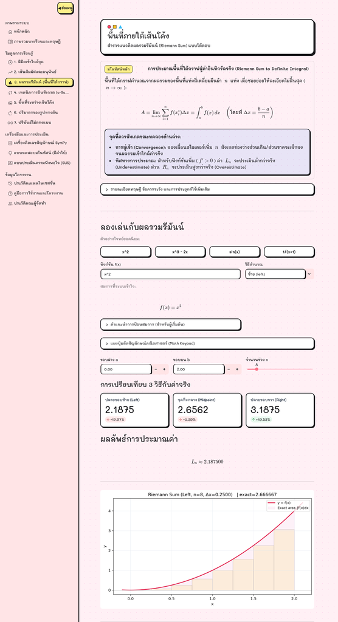

2.1.4 ทฤษฎี · เทคนิคการอินทิเกรต

การแทนค่าตัวแปร $u$ และการอินทิเกรตทีละส่วนด้วยหลักลำดับ LIATE

17 / 33

1. การแทนค่าตัวแปร $u$ (Substitution)

ใช้กฎลูกโซ่แบบย้อนกลับ: ให้ $u = g(x)$ จะได้ $du = g'(x)dx$

$$\int f(g(x))g'(x)\,dx = \int f(u)\,du$$

**ปริพันธ์จำกัดเขตต้องเปลี่ยนขอบเขต:** จาก $[a, b]$ สู่ $[g(a), g(b)]$ โดยไม่ต้องแปลงตัวแปรกลับ

2. ลำดับการเลือก $u$ ตามกฎ LIATE (จากสไลด์หัวข้อ)

สูตร By Parts: $\int u\,dv = uv - \int v\,du$ เรียงลำดับความสำคัญของ $u$:

- **L (Logarithmic):** $\ln x$ → ควรเป็น $u$ เสมอ (ดิฟง่าย แต่อินทิเกรตยาก)
- **I (Inverse Trig):** $\arctan x$ → ควรเป็น $u$ เสมอ (ดิฟแล้วเป็นพีชคณิต)
- **A (Algebraic):** $x^n$ → มักเป็น $u$ (ดิฟแล้วดีกรีลดลงเรื่อย ๆ)
- **T (Trigonometric):** $\sin x, \cos x$ → มักเป็น $dv$ (อินทิเกรตแล้ววนลูป)
- **E (Exponential):** $e^x$ → ควรเป็น $dv$ เสมอ (อินทิเกรตง่ายที่สุด)

2.1.4 ตัวอย่าง · การแทนค่า $u$ และ By Parts

ตัวอย่างที่ 2.8 และ 2.9: การคำนวณจริง และกับดักการเลือกตัวแปร By Parts

18 / 33

ตัวอย่างที่ 2.8: แทนค่า $u$

จงหาค่าของ $\int 2x\cos(x^2)\,dx$ ให้ $u = x^2 \implies du = 2x\,dx$

$$\int \cos(u)\,du = \sin(u) + C = \sin(x^2) + C$$

ระบบจะตรวจสอบว่า $2x$ ตัดทอนกับ $dx$ ได้หมดจดหรือไม่ หากไม่หมดจะแจ้งเตือน

ตัวอย่างที่ 2.9: กับดัก By Parts $\int x e^x dx$

**เลือกถูก (LIATE):** $u = x, dv = e^x dx \implies du = dx, v = e^x$  
$= x e^x - \int e^x dx = xe^x - e^x + C$ (ดีกรีลดลง)

**จุดเตือนเมื่อเลือกสลับ:** หากให้ $u = e^x, dv = x dx$ จะได้ $\frac{1}{2}x^2 e^x - \int \frac{1}{2}x^2 e^x dx$ พจน์ใหม่ดีกรีเพิ่มเป็น $x^2$ ซับซ้อนกว่าเดิมและวนลูป!

🌐 หน้าจอเว็บแอปจริง · การแทนค่าตัวแปรและ By Parts 🔍 คลิกขยาย

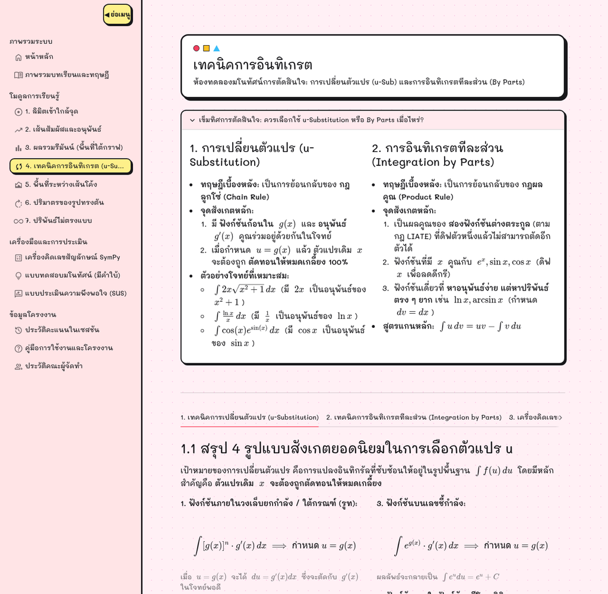

2.1.5 ทฤษฎี · พื้นที่ระหว่างเส้นโค้ง

นิยามพื้นที่ปิดล้อม และขั้นตอนวิธีแยกอินทิเกรตตามจุดตัดสลับระนาบ

19 / 33

นิยามพื้นที่ทางเรขาคณิต

กำหนดให้ $f(x)$ และ $g(x)$ เป็นฟังก์ชันต่อเนื่องบน $[a, b]$ พื้นที่ของบริเวณปิดล้อมคือ:

$$A = \int_a^b |f(x) - g(x)|\,dx$$

**ทำไมต้องมีค่าสัมบูรณ์:** หากเส้นโค้งตัดกันสลับบน-ล่าง การอินทิเกรตตรง ๆ โดยไม่ใส่ค่าสัมบูรณ์จะทำให้พื้นที่ส่วนบวกและลบ **หักล้างกันจนตอบ 0**

ขั้นตอนวิธีคำนวณ 4 ขั้นของระบบ

1. **หาจุดตัดทั้งหมด:** แก้สมการ $f(x) - g(x) = 0$ บนช่วง $[a, b]$
2. **แบ่งช่วงย่อย:** ใช้จุดตัดแบ่งช่วงเพื่อระบุว่าช่วงใด $f \ge g$ หรือ $g \ge f$
3. **คำนวณพื้นที่ย่อย:** $\int_{x_i}^{x_{i+1}} (y_{\text{บน}} - y_{\text{ล่าง}})\,dx$
4. **รวมผลลัพธ์สุทธิ:** รวมพื้นที่ของทุกช่วงย่อยเข้าด้วยกัน

2.1.5 ตัวอย่าง · พื้นที่ปิดล้อมและจุดตัดสลับระนาบ

ตัวอย่างที่ 2.10 และ 2.11: การคำนวณพื้นที่จริง และภาพกราฟิกแรเงา

20 / 33

ตัวอย่างที่ 2.10: พาราโบลากับแกน $x$

หาพื้นที่ปิดล้อมด้วย $y = 2x - x^2$ และแกน $x$ ($y=0$) บน $[0, 2]$

$$A = \int_0^2 |2x - x^2|\,dx = \int_0^2 (2x - x^2)\,dx = \left[x^2 - \frac{x^3}{3}\right]_0^2 = 4 - \frac{8}{3} = \frac{4}{3}\ \text{ตร.หน่วย}$$

**ตัวอย่างที่ 2.11: เส้นตรง $y=2x$ กับ $y=x^2$**  
จุดตัดคือ $x=0, 2$ ได้พื้นที่ $A = \int_0^2 (2x - x^2)dx = \frac{4}{3}$ ตร.หน่วย

🌐 หน้าจอเว็บแอปจริง · พื้นที่ระหว่างเส้นโค้งและการแรเงา 🔍 คลิกขยาย

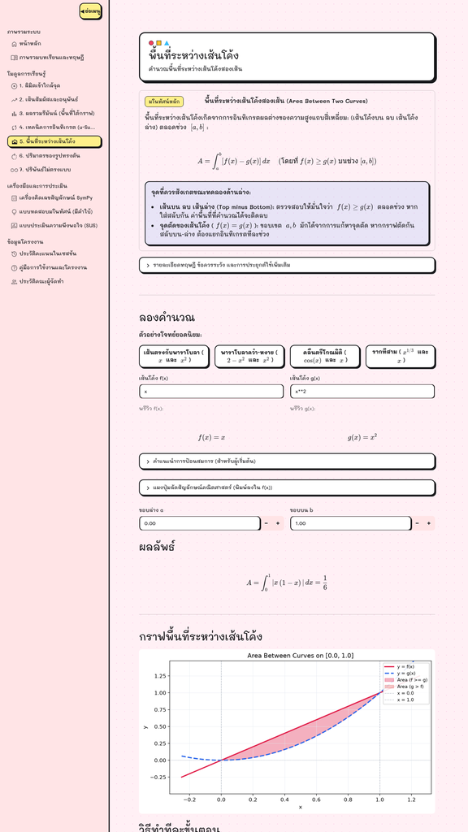

2.1.6 ทฤษฎี · ปริมาตรทรงตันจากการหมุน

วิธีจานกลม (Disk Method) และวิธีวงแหวน (Washer Method) รอบแกน $x$

21 / 33

1. วิธีจานกลม (Disk Method)

ใช้เมื่อบริเวณที่หมุนแนบชิดกับแกนหมุน โดยหน้าตัดเป็นรูปวงกลมตัน รัศมี $R(x) = f(x)$:

$$V = \pi \int_a^b [f(x)]^2\,dx$$

ที่มา: ผลบวกปริมาตรแผ่นจานทรงกระบอกบางสะสม $\sum \pi [f(x_i)]^2 \Delta x$

2. วิธีวงแหวน (Washer Method)

ใช้เมื่อบริเวณที่หมุนมีช่องว่าง/รูกลวง เกิดรัศมีนอก $R(x)$ และรัศมีใน $r(x)$:

$$V = \pi \int_a^b \left([R(x)]^2 - [r(x)]^2\right)\,dx$$

**จุดที่มักจำผิด:** สูตรต้องเป็น $\pi(R^2 - r^2)$ เสมอ ห้ามนำรัศมีมาลบกันก่อนยกกำลังสอง $\pi(R - r)^2$ เด็ดขาด

2.1.6 ตัวอย่าง · ปริมาตรทรงตันจากการหมุนรอบแกน $x$

ตัวอย่างที่ 2.12 (วิธีจาน) และ 2.13 (วิธีวงแหวน) พร้อมภาพหน้าตัดสะสม

22 / 33

ตัวอย่างที่ 2.12: วิธีจาน

หมุนบริเวณใต้กราฟ $y = \sqrt{x}$ จาก $x = 0$ ถึง $4$ รอบแกน $x$

$$V = \pi \int_0^4 (\sqrt{x})^2\,dx = \pi \int_0^4 x\,dx = \pi\left[\frac{x^2}{2}\right]_0^4 = 8\pi\ \text{ลบ.หน่วย}$$

ตัวอย่างที่ 2.13: วิธีวงแหวน

หมุนบริเวณปิดล้อมด้วย $y = x$ และ $y = x^2$ รอบแกน $x$ ($R=x, r=x^2$)

$$V = \pi \int_0^1 (x^2 - x^4)\,dx = \pi\left[\frac{x^3}{3} - \frac{x^5}{5}\right]_0^1 = \frac{2\pi}{15}\ \text{ลบ.หน่วย}$$

ระบบจะวาดภาพแว่นวงแหวนโปร่งใสซ้อนทับกัน ช่วยให้ผู้เรียนมองเห็นมโนทัศน์ของความหนา $\Delta x$ กลายเป็นปริมาตรทรงตัน 3 มิติ

🌐 หน้าจอเว็บแอปจริง · ปริมาตรทรงตันจากการหมุนรอบแกน x 🔍 คลิกขยาย

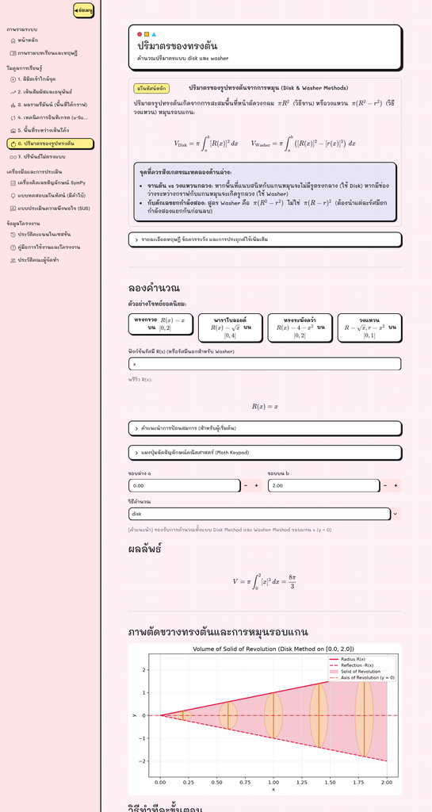

2.1.7 ทฤษฎี · ปริพันธ์ไม่ตรงแบบ

การจำแนกชนิดที่ 1 (ขอบเขตอนันต์) และชนิดที่ 2 (จุดเอกฐาน/หารด้วยศูนย์)

23 / 33

ชนิดที่ 1 · ขอบเขตเป็นอนันต์ (Infinite Interval)

ช่วงของการอินทิเกรตยาวถึงอนันต์ นิยามผ่านลิมิตของตัวแปร $t$:

$$\int_a^\infty f(x)\,dx = \lim_{t\to\infty} \int_a^t f(x)\,dx$$

หากลิมิตหาค่าเป็นจำนวนจริงได้ เรียกว่า **ลู่เข้า (Converges)** หากหาค่าไม่ได้ เรียกว่า **ลู่ออก (Diverges)**

ชนิดที่ 2 · มีจุดเอกฐาน (Discontinuous Integrand)

ฟังก์ชันมีค่าพุ่งสู่อนันต์ ณ จุด $c \in [a, b]$ ต้องแยกช่วงออกเป็น 2 ส่วน:

$$\int_a^b f(x)\,dx = \lim_{t\to c^-}\int_a^t f(x)\,dx + \lim_{s\to c^+}\int_s^b f(x)\,dx$$

**กฎความเข้มงวด:** ปริพันธ์จะลู่เข้าก็ต่อเมื่อลิมิตทั้งสองส่วนหาค่าได้พร้อมกัน ห้ามนำ $\pm\infty$ มาหักล้างกันให้เป็นศูนย์

2.1.7 ตัวอย่าง · การตรวจสอบการลู่เข้าและจุดเอกฐาน

ตัวอย่างที่ 2.14 และ 2.15: ปริพันธ์ลู่เข้า vs กรณีลู่ออกที่ห้ามหักล้าง

24 / 33

ตัวอย่างที่ 2.14: ชนิดที่ 1 (ลู่เข้าสู่ 1)

จงตรวจสอบการลู่เข้าของ $$\int_1^\infty \frac{1}{x^2}\,dx$$

$$\lim_{t\to\infty}\int_1^t x^{-2}dx = \lim_{t\to\infty}\left[-\frac{1}{x}\right]_1^t = \lim_{t\to\infty}\left(-\frac{1}{t} + 1\right) = 1$$

ตัวอย่างที่ 2.15: ชนิดที่ 2 (ลู่เข้าสู่ 2)

จงหาค่าของ $$\int_0^1 \frac{1}{\sqrt{x}}\,dx$$ (จุดเอกฐานที่ $x=0$)

$$\lim_{t\to 0^+}\int_t^1 x^{-1/2}dx = \lim_{t\to 0^+}\left[2\sqrt{x}\right]_t^1 = 2 - 0 = 2$$

🌐 หน้าจอเว็บแอปจริง · ปริพันธ์ไม่ตรงแบบและการตรวจสอบการลู่เข้า 🔍 คลิกขยาย

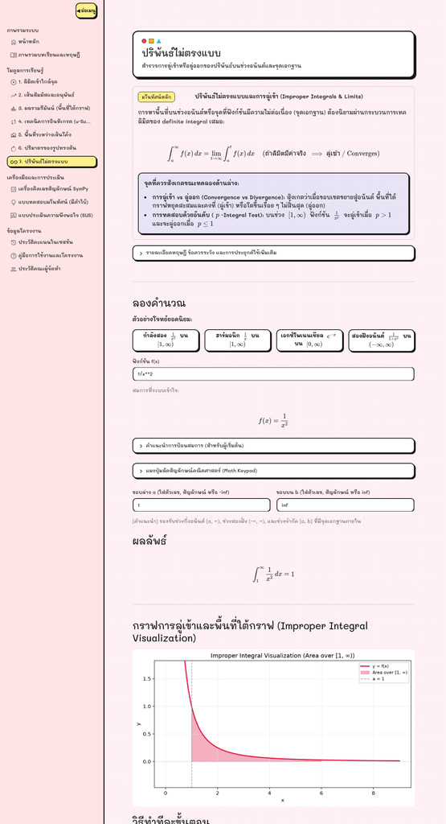

4. ผลการดำเนินงาน · คลังข้อสอบและระบบคำใบ้

คลังข้อสอบมโนทัศน์ 80 ข้อ พร้อมคำใบ้ 3 ระดับที่ไม่เฉลยคำตอบ

25 / 33

โครงสร้างแบบทดสอบมโนทัศน์

การดักจับจุดเข้าใจผิด

- ลืมใส่ค่าสัมบูรณ์ใน $\int \frac{1}{x}dx = \ln|x| + C$
- จำสูตรวงแหวนผิดเป็น $\pi(R - r)^2$
- ลืมเปลี่ยนขอบเขตตัวแปรในการแทนค่า $u$
- คิดว่า $\frac{0}{0}$ ตอบ 0 หรือ 1 หรือหาค่าไม่ได้ทันที

🌐 หน้าจอเว็บแอปจริง · คลังแบบทดสอบมโนทัศน์ 80 ข้อและระบบคำใบ้ 3 ระดับ 🔍 คลิกขยาย

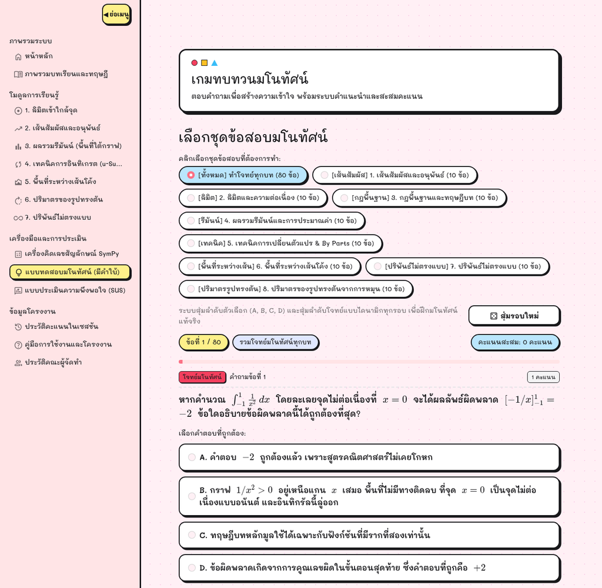

4. ผลการดำเนินงาน · ความถูกต้องทางเทคนิค

หลักฐานการทดสอบ: 265 กรณีหน่วยย่อย, 144 กรณีขอบเขต, 15 หน้าจอ

26 / 33

265

Pytest (ผ่าน 100%)

ทดสอบอัตโนมัติคลุมทุก Solver และตัวแปลงทางคณิตศาสตร์

144

Boundary Cases

กรณีขอบเขตวิกฤต จำแนกสิ่งที่รองรับและสิ่งที่ปฏิเสธ

15

หน้าจอระบบ

ทดสอบเสมือนจริงบนเบราว์เซอร์ ไม่พบ JavaScript error

ข้อจำกัดของการตีความผลทดสอบนี้

การทดสอบผ่านพิสูจน์ว่า **กรณีที่ประกาศรองรับทำงานถูกต้อง** และ **กรณีที่อยู่นอกขอบเขตถูกปฏิเสธอย่างชัดเจน** แต่ไม่ได้พิสูจน์ว่าถูกต้องสำหรับทุกอินพุต ทุกโจทย์ที่เป็นไปได้

5. ผลการประเมิน · ระเบียบวิธีและกลุ่มตัวอย่าง

ประเมินกับผู้ใช้จริง 50 คน ด้วยเครื่องมือมาตรฐาน 2 ชุด

27 / 33

เครื่องมือวัด 2 ชุด

**ชุดที่ 1 · ความพึงพอใจ 4 ด้าน (20 ข้อ)**  
มาตรประมาณค่า 5 ระดับ: UI/UX, ฟังก์ชันโต้ตอบ, เนื้อหามโนทัศน์, เจตคติและแรงจูงใจ

**ชุดที่ 2 · System Usability Scale (10 ข้อ)**  
คือแบบสอบถามมาตรฐาน 10 ข้อ ใช้มาตราส่วน 5 ระดับ เพื่อประเมินความสามารถในการใช้งาน (Usability) ของระบบจากมุมมองผู้ใช้ โดยมีคะแนนรวมตั้งแต่ 0–100 คะแนน

กลุ่มตัวอย่าง ($N = 50$)

บันทึกผล ณ วันที่ 30 ตุลาคม 2569 เวลา 10:15 น. รวม **$N = 50$ คน**

- ปริญญาตรีปี 3–4 **74%** · ปี 1–2 16% · บัณฑิตศึกษา 6%
- กำลังเรียนแคลคูลัส 30% · เคยสอบผ่านแล้ว 46%
- อุปกรณ์: แท็บเล็ต 40% · คอมพิวเตอร์ 34% · สมาร์ตโฟน 26%
- สังกัด: มก. กำแพงแสน 36%, ศิลปากร 24%, มรภ.ธนบุรี 12%, อื่น ๆ 28%

5. ผลการประเมิน · ความพึงพอใจของผู้ใช้งาน

ภาพรวมอยู่ในระดับมากที่สุด 4.63 จาก 5.00 ($S.D. = 0.58$)

28 / 33

| ด้านการประเมิน | $\bar{x}$ | $S.D.$ | ระดับ |
| --- | --- | --- | --- |
| 1. การออกแบบส่วนประสานงาน (UI/UX) | 4.62 | 0.60 | มากที่สุด |
| 2. ฟังก์ชันเชิงโต้ตอบและการคำนวณ | 4.60 | 0.61 | มากที่สุด |
| 3. เนื้อหาและมโนทัศน์ทางคณิตศาสตร์ | 4.64 | 0.56 | มากที่สุด |
| 4. เจตคติและแรงจูงใจในการเรียนรู้ | **4.67** | 0.56 | มากที่สุด |
| ภาพรวมทุกด้าน | 4.63 | 0.58 | มากที่สุด |

อ่านผลอย่างไรให้ไม่เกินจริง

คะแนนสูงสุดคือด้าน **เจตคติและแรงจูงใจ (4.67)** ซึ่งสอดคล้องกับสมมติฐานว่า การเห็นภาพและการทดลองช่วยลดความวิตกกังวลต่อวิชาแคลคูลัส

แต่คะแนนนี้คือ **การรับรู้ของผู้เรียน (Perceived)** ไม่ใช่หลักฐานว่าผลสัมฤทธิ์ทางการเรียนสูงขึ้น ซึ่งต้องใช้การทดลอง Pre/Post-test ในงานวิจัยขั้นต่อไป

$$\bar{x} = 4.63,\quad S.D. = 0.58,\quad N = 50$$

5. ผลการประเมิน · ความสะดวกในการใช้งาน (SUS)

SUS 82.15 (Grade A) และการอ่านผลอย่างโปร่งใส ($n=29$ ได้ 73.53)

29 / 33

คะแนนรวม ($N = 50$)

82.15

$S.D. = 19.36$ · มัธยฐาน 87.50 · เกณฑ์มาตรฐานอุตสาหกรรม 68.0

$$\text{SUS} = 2.5\sum_{i=1}^{10} s_i,\quad s_i = X_i - 1$$

จัดอยู่ในเกณฑ์ยอดเยี่ยม Grade A (Brooke, 1996; Sauro, 2011)

ความลำเอียงที่พบ และวิธีจัดการ

- พบการกาดิ่ง (ตอบคะแนนเท่ากันทุกข้อ) **21 คน คิดเป็น 42%**
- เมื่อแยกกลุ่มที่มีการกระจายคะแนนตามธรรมชาติ ($n=29$) คะแนนเฉลี่ยอยู่ที่ **73.53** ($S.D.=15.95$)
- ยังคงอยู่ในระดับ **Grade B (Good)** และสูงกว่าเกณฑ์ 68.0

เรารายงานทั้งสองค่าในบทที่ 4 และบทคัดย่อ เพื่อความโปร่งใสทางวิชาการ

6. ข้อคิดเห็นและ Demand ของผู้เรียน

30 / 33

| หัวข้อที่ต้องการเพิ่ม | จำนวน | ร้อยละ |
| --- | --- | --- |
| อินทิเกรตทีละส่วน (By Parts) | 29 | 58.0% |
| แยกเศษส่วนย่อย (Partial Fractions) | 25 | 50.0% |
| แทนค่าฟังก์ชันตรีโกณมิติ | 22 | 44.0% |
| แบบจำลอง 3 มิติสำหรับการหมุน | 21 | 42.0% |

ข้อกังวลที่ผู้เรียนสะท้อน

- **โทนสีสดใส:** เลือกใช้สไตล์ Bauhaus เพื่อลดความเครียด สอดคล้องกับเจตคติ 4.67
- **ตัวหนังสือเยอะ:** ยืนยันว่าระบบเป็นห้องทดลอง ไม่ใช่เครื่องแจกคำตอบ
- **จอมือถือ:** วางแผนปรับ Responsive สำหรับมือถือในรุ่นถัดไป

7. ข้อจำกัด

ข้อจำกัด และหมายเหตุ

31 / 33

ข้อจำกัดทางคณิตศาสตร์ที่ค้นพบ

- ฟังก์ชันไม่มีปฏิยานุพันธ์มูลฐาน ($e^{-x^2}, \frac{\sin x}{x}$) ระบบแจ้งเตือนหยุดคำนวณ
- ปริมาตรทรงตันรองรับการหมุนรอบแกน $x$ เท่านั้น
- ฟังก์ชันที่แกว่งตัวรุนแรง ($\sin\frac{1}{x}$) ระบบรายงานว่าลิมิตหาค่าไม่ได้ ซึ่งถูกต้องตามหลักคณิตศาสตร์ แต่เส้นกราฟอาจเกิดรอยหยักจากการสุ่มตัวอย่างไม่ถี่พอ (Aliasing)

หมายเหตุเล่มส่งกรรมการ (120 หน้า)

- **ภาคผนวก ง:** เฉลยเป็น ก ทั้ง 16 ข้อ แต่ในหน้า webapp จะทำการสุ่มตัวเลือกใหม่ทุกครั้ง
- **สารบัญภาพ:** เลขหน้าภาพที่ 12 คลาดเคลื่อน 2 หน้าจากการแทรก QR Code เว็บจริง

8. ข้อเสนอแนะและบทสรุป

แนวทางต่อยอด 3 ด้าน และการตอบโจทย์วัตถุประสงค์ทั้ง 5 ข้อ

32 / 33

ด้านเนื้อหา

เพิ่ม By Parts (58%) และ Partial Fractions (50%) พร้อมวิธีเปลือกทรงกระบอก (Cylindrical Shells)

ด้านประสบการณ์ผู้ใช้

ปรับระบบ Responsive ให้ลื่นไหลบนมือถือ 100% และเพิ่มโมเดล 3D WebGL สำหรับการหมุนทรงตัน

ด้านการวิเคราะห์การเรียนรู้

เชื่อมต่อฐานข้อมูลเก็บ Log การทำแบบทดสอบเพื่อวัดผลสัมฤทธิ์ Pre/Post-test อย่างเป็นทางการ

**ตอบวัตถุประสงค์ครบ 5 ข้อ:** เว็บแอป 15 หน้าใช้งานได้จริง • ครบ 7 โมดูล • SymPy คำนวณถูกต้องผ่านการทดสอบ 265 ข้อ • ป้องกัน Misconceptions ด้วยคำใบ้ • ประเมินความพึงพอใจ 4.63 และ SUS 73.53 (Good)

ขอขอบคุณคณะกรรมการทุกท่าน

ขอบคุณค่ะ / พร้อมรับฟังข้อซักถาม

• โครงงานคณิตศาสตร์ประยุกต์ 2569

33 / 33

เว็บแอปพลิเคชันจริง

[calculus-integration-app.streamlit.app](https://calculus-integration-app-dwdsz8vq2omsddezfjvday.streamlit.app/)

[figure not shown]

ซอร์สโค้ดและรายงาน

**GitHub:** SubwatG/calculus-integration-app  
**เล่มรายงาน:** ฉบับส่งกรรมการ (120 หน้า)

คณะผู้วิจัย

1. ขวัญเรือน สำเนียงดี (แอร์)  
2. เบญจกัฬยาณี พิทยากูล (ชิชา)  
อ.ดร.กิตติพงศ์ ทรัพย์วัฒนาชัย (ที่ปรึกษา)

ช่วงตอบข้อซักถามและรับฟังข้อเสนอแนะจากคณะกรรมการ

Calculus Learning Sandbox • รายงานโครงงานคณิตศาสตร์ประยุกต์ 2569

Slide 1 of 34